# DS 3000 Final Project: Ocean Depth Temperature-Ideal Times

## Team 8

- Kiran Bajaj (bajaj.ki@northeastern.edu)
- Katelyn Donn (donn.k@northeastern.edu)
- Ahmed Bekdash (bekdash.a@northeastern.edu)
- Zeynep Duzgun (duzgun.z@northeastern.edu)
- Augusta Crow (crow.a@northeastern.edu)

# Executive Summary

We are creating a way to see how accurate regression models are on the data from a [research project](https://helmuthlab.cos.northeastern.edu/databases/robomussel/) when the increments of when the temperature are taken are further apart. We first found the ideal degree to use on our original data set and plotted a regression model to see what we were comparing to. We then created a function that determined the $r^2$ value of a regression model when every $1/n$ of the original temperatures and times are included. For our final step, we plotted the $r^2$ values to see what increments are best to keep a similar model to our original. From this model we were able to determine that if the temperature was taken every 3.5 days at a depth of 2 meters, the model would have a $r^2$ of around 0.6 which is close to our original $r^2$ value of 0.72. We suggest that the model would work better if it could take in more specific values and if it could be tested on an area that has more temperature fluctuation.

# Ethical Considerations

As this data is taken in a sceintific context, it is hard to find bias within it. As the research project is trying to find a disparity between temperatures at different depths, it is important to note that this fact may have played a role in the chosen location. Another motivation around choosing the location of the research project was an additional project to see how the different temperatures impact intertidal mussels and barnacles.

# Introduction

This project aims to approximate how often it is necessary to measure ocean temperature for accurate results. Our motivation behind obtaining such measurements is due to increasing ocean temperatures. Currently, ocean temperature is measured aerially, and it is more accurate to measure it at specific depths which is what our device is measuring. As this device is a newer technology, it is more expensive to use and since the temperature is taken every ten minutes, the device has to sit in the same area for prolonged periods of time. As it is crucial to measure ocean temperature accurately in the whole ocean to monitor the effects of climate change, cost effectiveness and resource allocation are issues to consider with this device. **The goal of this project is to create a more cost effective way for the scientists to measure the temperature and we believe a similar temperature model can be created when the temperature is taken in less frequent increments than every 10 minutes.**

# Data Description

### Pipelining Process

```python
import pandas as pd

# reading the files of data for each depth
df_two_m_data = pd.read_csv('BZSCCB9_forereef_inner_2m.csv')
df_twenty_m_data = pd.read_csv('BZSCCB6_forereef_inner_20m.csv')
df_ten_m_data = pd.read_csv('BZSCCB4_forereef_inner_10m.csv')
df_five_m_data = pd.read_csv('BZSCCB3_forereef_inner_5m.csv')

df_five_m_data.head()
```

|  | site | district | country | site_code | lat | long | reef_habitat | depth_m | time_gmt | temp_c |
| --- | --- | --- | --- | --- | --- | --- | --- | --- | --- | --- |
| 0 | Carrie Bow Caye | Stann Creek | Belize | BZSCCB3 | 16.8009 | -88.079817 | forereef_inner | 5 | 2001-03-17 22:30:00 | 27.02 |
| 1 | Carrie Bow Caye | Stann Creek | Belize | BZSCCB3 | 16.8009 | -88.079817 | forereef_inner | 5 | 2001-03-17 22:40:00 | 27.12 |
| 2 | Carrie Bow Caye | Stann Creek | Belize | BZSCCB3 | 16.8009 | -88.079817 | forereef_inner | 5 | 2001-03-17 22:50:00 | 27.12 |
| 3 | Carrie Bow Caye | Stann Creek | Belize | BZSCCB3 | 16.8009 | -88.079817 | forereef_inner | 5 | 2001-03-17 23:00:00 | 27.03 |
| 4 | Carrie Bow Caye | Stann Creek | Belize | BZSCCB3 | 16.8009 | -88.079817 | forereef_inner | 5 | 2001-03-17 23:10:00 | 27.03 |

```python
df_two_m_data['dates'] = pd.to_datetime(df_two_m_data['time_gmt']).dt.date
df_two_m_data['time'] = pd.to_datetime(df_two_m_data['time_gmt']).dt.time

df_five_m_data['dates'] = pd.to_datetime(df_five_m_data['time_gmt']).dt.date
df_five_m_data['time'] = pd.to_datetime(df_five_m_data['time_gmt']).dt.time

df_ten_m_data['dates'] = pd.to_datetime(df_ten_m_data['time_gmt']).dt.date
df_ten_m_data['time'] = pd.to_datetime(df_ten_m_data['time_gmt']).dt.time

df_twenty_m_data['dates'] = pd.to_datetime(df_twenty_m_data['time_gmt']).dt.date
df_twenty_m_data['time'] = pd.to_datetime(df_twenty_m_data['time_gmt']).dt.time
```

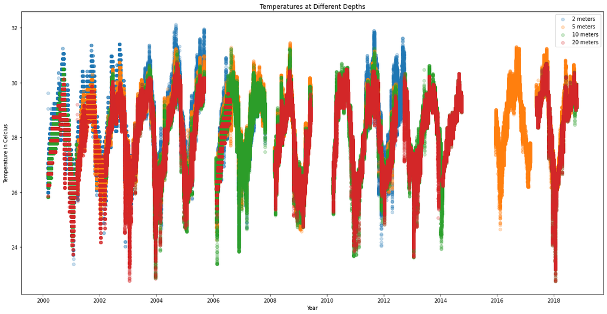

```python
import matplotlib.pyplot as plt
y_val_2 = df_two_m_data['temp_c']
y_val_5 = df_five_m_data['temp_c']
y_val_10 = df_ten_m_data['temp_c']
y_val_20 = df_twenty_m_data['temp_c']

x_val_2 = df_two_m_data['dates']
x_val_5 = df_five_m_data['dates']
x_val_10 = df_ten_m_data['dates']
x_val_20 = df_twenty_m_data['dates']

plt.scatter(x_val_2, y_val_2, label = '2 meters', alpha=0.25)
plt.scatter(x_val_5, y_val_5, label = '5 meters', alpha =0.25)
plt.scatter(x_val_10, y_val_10, label = '10 meters', alpha=0.25)
plt.scatter(x_val_20, y_val_20, label = '20 meters', alpha = 0.25)

plt.legend()
plt.title('Temperatures at Different Depths')
plt.xlabel('Year')
plt.ylabel('Temperature in Celcius')
plt.gcf().set_size_inches(20, 10)
```

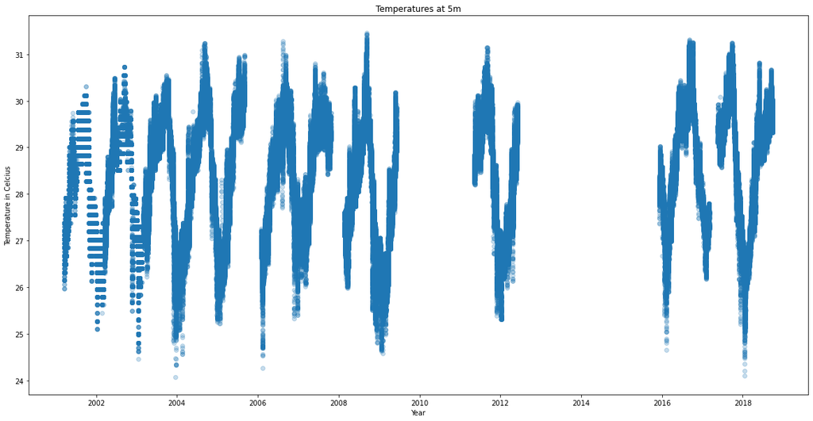

```python
plt.scatter(x_val_5, y_val_5, label = '5 meters', alpha =0.25)

plt.title('Temperatures at 5m')
plt.xlabel('Year')
plt.ylabel('Temperature in Celcius')
plt.gcf().set_size_inches(20, 10)
```

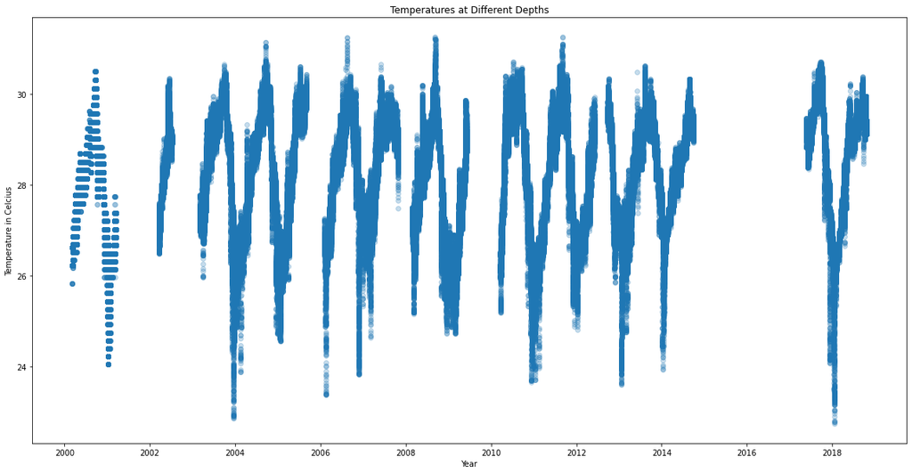

```python
plt.scatter(x_val_10, y_val_10, label = '10 meters', alpha=0.25)

plt.title('Temperatures at Different Depths')
plt.xlabel('Year')
plt.ylabel('Temperature in Celcius')
plt.gcf().set_size_inches(20, 10)
```

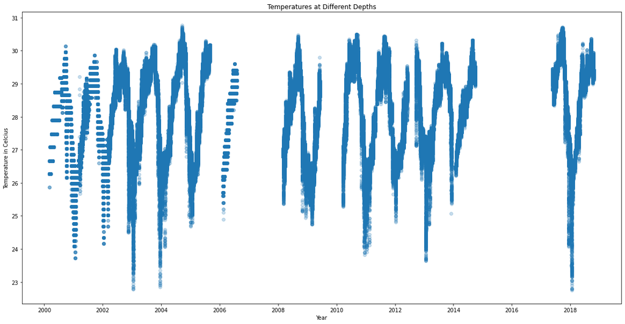

```python
plt.scatter(x_val_20, y_val_20, label = '20 meters', alpha = 0.25)

plt.title('Temperatures at Different Depths')
plt.xlabel('Year')
plt.ylabel('Temperature in Celcius')
plt.gcf().set_size_inches(20, 10)
```

We considered this data to be reliable because it is taken by a very meticulous device and is measured very frequently. We also trusted that the Northeastern PhD student who supplied that data had validated its reliability given that the student is using it for their own analysis. As for the problems we expected to encounter with these datasets, we were overwhelmed by the sheer amount of data we had to process. Each of our four datasets contained hundreds of thousands of measurements because the temperature is recorded so frequently.

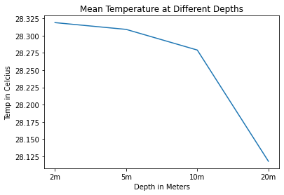

```python
import matplotlib.pyplot as plt
# the mean temperatures for each depth
x_vals = ('2m', '5m', '10m', '20m')
y_vals = (df_two_m_data['temp_c'].mean(), df_five_m_data['temp_c'].mean(),
          df_ten_m_data['temp_c'].mean(),df_twenty_m_data['temp_c'].mean())

# plots the mean temperature at each depth
plt.plot(x_vals, y_vals)
plt.title('Mean Temperature at Different Depths')
plt.xlabel('Depth in Meters')
plt.ylabel('Temp in Celcius');
```

Since a depth of 2 meters had the highest average temperature, we decided to choose that depth to call our regression model on since high temperatures are crucial for climate change and because majority of animals in the ocean are located closer to the shore.

```python
# use this to separate the data and time
df_two_m_data['dates'] = pd.to_datetime(df_two_m_data['time_gmt']).dt.date
df_two_m_data['time'] = pd.to_datetime(df_two_m_data['time_gmt']).dt.time

# dropping any rows with NaN values
df_two_m_data.dropna(axis = 0, inplace = True)
```

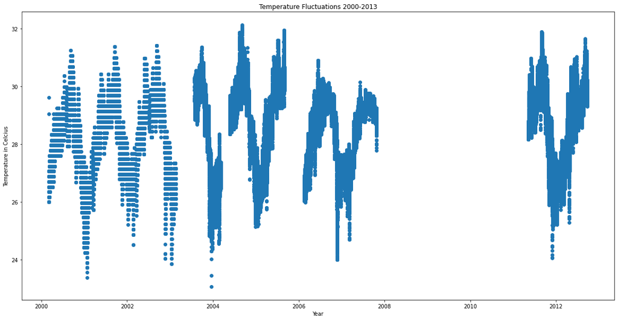

```python
# graph of the 2m temperatures throughout the time frame
plt.scatter(df_two_m_data['dates'], df_two_m_data['temp_c'])
plt.title('Temperature Fluctuations 2000-2013')
plt.xlabel('Year')
plt.ylabel('Temperature in Celcius')
plt.gcf().set_size_inches(20, 10)
```

## More Pipelining of Data for Regression

We can see from the above graph that when we remove the rows that don't contain any values(NaN), it gets rid of the data from 2008 to 2011 which means we should narrow the amount of data we are looking at to a time range in which the data was collected consistently. We decided to choose a year as the period of time we wanted to apply our regression model to as we believed that a year was a good amount of time to test our data on as temperature seems to fluctuate in similar ways annually. We specifically chose the year 2000 because we believed that the first year that the data was taken was going to be the data that was collected in the most consistent way.

Before we did that, we wanted to make sure that the data was split into columns of year, month, day, hour, minute, and second in order to use those columns as features later. We also had to turn the values within those columns into integers or floats in order for them to work later.

```python
# separates the date column into separate year, month, day columns
df_two_m_data['dates'] = pd.to_datetime(df_two_m_data['dates'])
df_two_m_data['year']= df_two_m_data['dates'].dt.year
df_two_m_data['month']= df_two_m_data['dates'].dt.month
df_two_m_data['day']= df_two_m_data['dates'].dt.day
```

```python
# separates time column into hour, minute, second columns and makes type a int
for idx, val in df_two_m_data.iterrows():
    df_two_m_data.loc[idx, 'hour'], df_two_m_data.loc[idx, 'minute'], df_two_m_data.loc[idx, 'second'] = [int(num) for num in str((df_two_m_data.loc[idx, 'time'])).split(':')]
```

```python
# defines the year we want our data from
years = (df_two_m_data['year'] > 1999) & (df_two_m_data['year'] <= 2000)

# creates data frame with only data from 2000
df_two_m_years = df_two_m_data.loc[years]
df_two_m_years.head()
```

|  | site | district | country | site_code | lat | long | reef_habitat | depth_m | time_gmt | temp_c | dates | time | year | month | day | hour | minute | second |
| --- | --- | --- | --- | --- | --- | --- | --- | --- | --- | --- | --- | --- | --- | --- | --- | --- | --- | --- |
| 0 | Carrie Bow Caye | Stann Creek | Belize | BZSCCB9 | 16.8009 | -88.079817 | forereef_inner | 2 | 2000-03-04 21:30:00 | 29.61 | 2000-03-04 | 21:30:00 | 2000 | 3 | 4 | 21.0 | 30.0 | 0.0 |
| 1 | Carrie Bow Caye | Stann Creek | Belize | BZSCCB9 | 16.8009 | -88.079817 | forereef_inner | 2 | 2000-03-04 21:40:00 | 29.05 | 2000-03-04 | 21:40:00 | 2000 | 3 | 4 | 21.0 | 40.0 | 0.0 |
| 2 | Carrie Bow Caye | Stann Creek | Belize | BZSCCB9 | 16.8009 | -88.079817 | forereef_inner | 2 | 2000-03-04 21:50:00 | 26.70 | 2000-03-04 | 21:50:00 | 2000 | 3 | 4 | 21.0 | 50.0 | 0.0 |
| 3 | Carrie Bow Caye | Stann Creek | Belize | BZSCCB9 | 16.8009 | -88.079817 | forereef_inner | 2 | 2000-03-04 22:00:00 | 26.70 | 2000-03-04 | 22:00:00 | 2000 | 3 | 4 | 22.0 | 0.0 | 0.0 |
| 4 | Carrie Bow Caye | Stann Creek | Belize | BZSCCB9 | 16.8009 | -88.079817 | forereef_inner | 2 | 2000-03-04 22:10:00 | 26.70 | 2000-03-04 | 22:10:00 | 2000 | 3 | 4 | 22.0 | 10.0 | 0.0 |

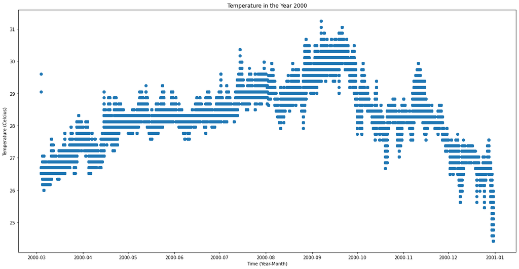

```python
# plots the temperature data from the year 2000
plt.scatter(df_two_m_years['dates'], df_two_m_years['temp_c']);
plt.gcf().set_size_inches(20, 10)
plt.xlabel('Time (Year-Month)')
plt.ylabel('Temperature (Celcius)')
plt.title('Temperature in the Year 2000')
```

### Validating the Datatype of the Y-Values

In order for our regressor to work, we needed to validate that the features we were using for x and y were in either the int or float value as conversion from the datetime type tended to result in a object data type which we couldn't work with.

```python
# determining data types of wanted feature values
df_two_m_years.dtypes.tail(9)
```

```
temp_c           float64
dates     datetime64[ns]
time              object
year               int64
month              int64
day                int64
hour             float64
minute           float64
second           float64
dtype: object
```

# Method

We decided to use polynomial regression to accurately depict a graphical representation of our data and create a prediction for future temperatures. Since our data fluctuates with the time of day and the seasons, a polynomial regression makes more sense than a simple linear regression as it can follow the curve and pattern of the data better. Additionally, we decided against a random forest classifier or a decision tree as our data would be more visually informative in the form of a regression line (because we’re only predicting temperature based on depths). Since the data does follow more of a wave-like pattern this type of regression may prove difficult since we have't learned how to apply regression for data that looks like that.

## Polynomial Determination

```python
from sklearn.preprocessing import PolynomialFeatures
from sklearn.model_selection import KFold
from sklearn.linear_model import LinearRegression
import numpy as np
import matplotlib.pyplot as plt
from sklearn.metrics import r2_score
from tqdm import tqdm

# defines features used
x = df_two_m_years.loc[:, ['year','month', 'day', 'hour', 'minute', 'second']]
y = df_two_m_years['temp_c'].values

# determines splots and maz degree
n_splits = 10
max_degree = 9

# init cross validation & regression obj
lin_reg = LinearRegression(fit_intercept=False)
kfold = KFold(n_splits=n_splits, shuffle=True)

# designates r2 dict to add values to
r2_dict = dict()
# tests degrees from 1 to 9
for degree in tqdm(range(1, max_degree)):
    # project into polynomial features of proper degree
    poly_feat = PolynomialFeatures(degree=degree)
    x_poly = poly_feat.fit_transform(x)

    # cross validation loop
    y_pred = np.empty_like(y)
    for train_idx, test_idx in kfold.split(x):
        # split data into train / test
        x_poly_train = x_poly[train_idx, :]
        x_poly_test = x_poly[test_idx, :]
        y_train = y[train_idx]

        # fit from train data, predict from test
        lin_reg.fit(x_poly_train, y_train)
        y_pred[test_idx] = lin_reg.predict(x_poly_test)

    # compute / store cross validated r2 score
    r2_dict[degree] = r2_score(y_pred=y_pred, y_true=y)
```

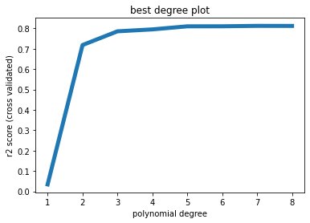

```python
# plots which degree is best to get the best r2 score
plt.plot(r2_dict.keys(), r2_dict.values(), linewidth=5)
plt.xlabel('polynomial degree')
plt.ylabel('r2 score (cross validated)')
plt.title('best degree plot');
```

From this best degree plot, it is clear that the $r^2$ value seems to stop increasing around 2 degrees which was how we detwermined that value to be best for our regression model

## Model

```python
# for visual purposes: takes a month within the year to plot
df_1 = df_two_m_years[df_two_m_years['month'] == 3]
```

```python
# used from lecture slides

def coef_to_poly_str(coef, include_zero=False):
    """ creates a str of polynomial corresponding to coef

    Args:
        coef (np.array): coefficients of polynomial

    Returns:
        poly_str (str): str of polynomial
    """
    # designates list to add values to
    str_monomial_list = []

    for deg, coef in enumerate(coef):
        if coef == 0 and include_zero == False:
            # this coefficient is zero, just skip it altogether
            continue

        # turns the coefficient into a string
        str_monomial_list.append(f'{coef:+.1f} x^{deg:d}')

    # returns the equation a string
    return 'y = ' + ' '.join(str_monomial_list)
```

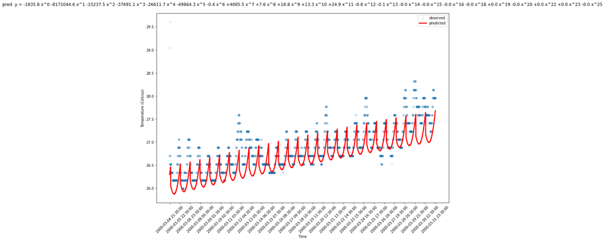

```python
# defines the degree
degree = 2

# defines the features for x and y values
x = df_two_m_years.loc[:, ['year','month', 'day', 'hour', 'minute', 'second']]
original_y = df_two_m_years['temp_c'].values

x_2 = df_1.loc[:, ['year','month', 'day', 'hour', 'minute', 'second']]

# process x to polynomial features
poly_feat = PolynomialFeatures(degree=degree)
x_poly = poly_feat.fit_transform(x)

# fit polynomial regression
reg = LinearRegression(fit_intercept=False)
reg.fit(x_poly, original_y)

# predict y (from regression)
original_y_pred = reg.predict(x_poly)

# month of fitting and prediction for plotting
x_2_poly = poly_feat.fit_transform(x_2)
y_pred_2 = reg.predict(x_2_poly)

# plot
plt.scatter(df_1['time_gmt'], df_1['temp_c'].values, label='observed', alpha=0.1)
plt.plot(df_1['time_gmt'], y_pred_2, color='r', linewidth=3, label='predicted')
plt.xlabel('Time')
plt.ylabel('Temperature (Celcius)')

# makes the x labels easier to read
plt.xticks(df_1.iloc[::150, 8])
plt.xticks(rotation = 45)

# collect coefficients
coef_pred = reg.coef_
str_poly_pred = coef_to_poly_str(coef_pred)

# adds a title of the predicted equation
plt.title(f'pred: {str_poly_pred}\n')

# legend and size of graph
plt.legend()
plt.gcf().set_size_inches(15, 10)
```

### Observations

We can see from the title of the graph that the degree of the regression is much larger than 2. It makes sense that the regression line would appear the way that it does since it is plotting temperature over time which fluctuates every day. Every peak in the regression line aligns with the hottest point in the day for every day in the month of March. The regression line is clearly very complicated which is why the equation of the line is included in our computation.

# Results

## Estimation

This shows our $r^2$ value from the regression model above when we plot the regression against the data before it was put into increments. We will use this score to determine at what point is a $r^2$ value a good $r^2$ value when the increments are taken out. We don't want the value we get to be too far away from the original value.

```python
# r2 score of the original regression model
r2_score(y_pred=original_y_pred, y_true=y)
```

```
0.7176493999041949
```

## Function

```python
def interval_regress(divider):
    """ divides the data into intervals and finds the r2 value of
    the regression compared to the regression of the original data

    Args:
        divider(int): the intervals of 10 the data is split into
    """
    # separates the data by every into increments determined by the divider
    new_df = df_two_m_years.iloc[::divider, :]

    # designates the degree of the regression
    degree = 2

    # defines the x and y values
    x = new_df.loc[:, ['year','month', 'day', 'hour', 'minute', 'second']]
    y = new_df['temp_c'].values

    # fit polynomial regression
    poly_feat = PolynomialFeatures(degree=degree)
    x_poly = poly_feat.fit_transform(x)

    # predict y (from regression)
    y_pred = reg.predict(x_poly)

    # calculates the r2 score
    r2_val = r2_score(y_pred=y_pred, y_true=y)

    return r2_val
```

## Validation

- If this value is close to 1, then the time increment of temperature taken will create a similar model to the original model.
- If this value is close to zero, then the time increment of temperature taken will not create a similar enough model.
- If this value is negative, then the time increment of temperature taken will be nothing like the original model.

## Visualization

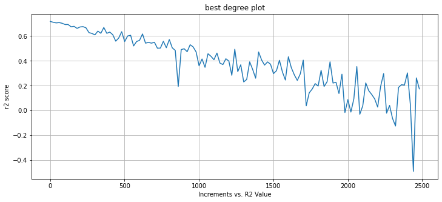

```python
# designates lists for values to be added to
x_values = []
y_values = []

# tests increments from original to 2500
for val in range(1, 2500, 20):

    # y values are r2 value of regression
    y_values.append(interval_regress(val))

    # x values are the increments tested
    x_values.append(val)

# plots the values
plt.plot(x_values, y_values)
plt.grid(True)
plt.gcf().set_size_inches(12, 5)
plt.xlabel('Increments vs. R2 Value')
plt.ylabel('r2 score')
plt.title('best degree plot');
```

```python
# r2 score when temp taken every 3.5 days
interval_regress(500)
```

```
0.594952823975351
```

# Discussion

The results showed that our prediction model was accurate, with an $r^2$ score of 0.717. With this model, we could answer our original question of how often a temperature measurement is necessary to get an accurate result using a function that calculated the $r^2$ of models on the data when increments were removed. Using the function, we saw that a dropoff below 0.6 in $r^2$ only occurred at around 500 ten-minute increments or 3.5 days. Since at this increment the $r^2$ score was around 0.6, we could say it was close to our original model because it is only a 0.117 decrease in $r^2$ and still is close to the ideal value of 1. This is significant since our original dataset measured temperature every ten minutes and our results show that measuring every 3.5 days would not substantially affect the results.

The challenges we faced during our project were mainly with our data. The dataset we used was very simple and we could only use temperature for our analysis. This made our options limited in terms of any graphs or research on the data. Our group also had trouble when constructing the machine-learning part of the project, specifically when calculating the $r^2$ score of the model. It also was fairly confusing that the best degree for our data was determined to be 2 because there was clearly more than 2 degrees once we plotted our regression line.

## Takeaway:

These results are significant since measuring the temperature less often and still getting accurate data would reduce the overall cost of the project making the temperature taking device more cost effective. The cost to maintain the measuring device would certainly go down and it could even be moved to other locations in the time between measurements. This would save money and time in projects where measurements in several locations are needed. These results were both expected and unexpected to our team because we agreed that measurements every ten minutes were unnecessary, but we did not expect that measurements every three and a half days would be around as accurate.

One question we would like to answer before implementing any change would be how accurate is the model on locations other than Belize. Would a colder climate change the results? Would a more volatile climate change the results? That way, we could be more confident in our prediction in locations around the world. It would also be ideal if our function was modified to take in values that are more specific than increments of ten (as in days, weeks, years, etc.)

```python
import pandas as pd
import matplotlib.pyplot as plt
from collections import defaultdict

df_two_m_data = pd.read_csv('BZSCCB9_forereef_inner_2m.csv')
df_twenty_m_data = pd.read_csv('BZSCCB6_forereef_inner_20m.csv')
df_ten_m_data = pd.read_csv('BZSCCB4_forereef_inner_10m.csv')
df_five_m_data = pd.read_csv('BZSCCB3_forereef_inner_5m.csv')


def remove_time(data):
    data.dropna(axis = 0, inplace = True)
    data_list = []
    for t in data.loc[:,'time_gmt']:
        date, time = t.split(" ")
        data_list.append(date)
    data['time_gmt'] = data_list
    return data


def remove_day(data):
    date_list = []
    year_list = []
    for t in data.loc[:,'time_gmt']:
        year, month,day = t.split("-")
        date_list.append(str(year) + '-' +str(month))
        #year_list.append(year)

    data['time_gmt'] = date_list
    return data

def iso_year(data,target_year):
    temp_dict = defaultdict(lambda:0)
    for i in range(len(data)):
         if int(data.index[i].split('-')[0]) == target_year:
            temp_dict[data.index[i]] = data.loc[data.index[i],'temp_c']

    return temp_dict

def plot(temp_dict,label):
    plt.scatter(x = temp_dict.keys(),y= temp_dict.values(), label = label)
    plt.plot(temp_dict.keys(),temp_dict.values())
```

```python
df_two_m_data = remove_time(df_two_m_data)
df_two_m_data = remove_day(df_two_m_data)
df_average_two = df_two_m_data.groupby("time_gmt").mean()

df_twenty_m_data = remove_time(df_twenty_m_data)
df_twenty_m_data = remove_day(df_twenty_m_data)
df_average_twenty = df_twenty_m_data.groupby("time_gmt").mean()

df_ten_m_data = remove_time(df_ten_m_data)
df_ten_m_data = remove_day(df_ten_m_data)
df_average_ten = df_ten_m_data.groupby("time_gmt").mean()

df_five_m_data = remove_time(df_five_m_data)
df_five_m_data = remove_day(df_five_m_data)
df_average_five = df_five_m_data.groupby("time_gmt").mean()

two_m_dict = iso_year(df_average_two, 2002)
twenty_m_dict = iso_year(df_average_twenty, 2002)
ten_m_dict = iso_year(df_average_ten, 2002)
five_m_dict = iso_year(df_average_five, 2002)
```

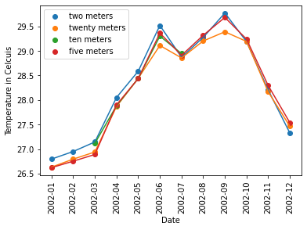

```python
plot(two_m_dict,'two meters')
plot(twenty_m_dict,'twenty meters')
plot(ten_m_dict,'ten meters')
plot(five_m_dict,'five meters')
plt.xticks(rotation = 90);
plt.legend()
plt.xlabel('Date')
plt.ylabel('Temperature in Celcuis')
```

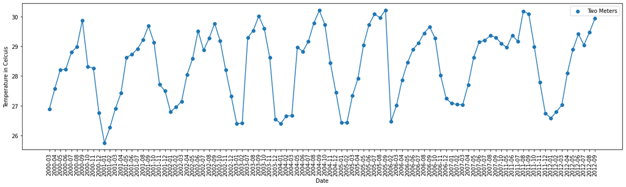

```python
plt.figure().gca().scatter(x=df_average_two.index,y=df_average_two['temp_c'], label = 'Two Meters')
plt.plot(df_average_two.index,df_average_two['temp_c'])

plt.gcf().set_size_inches(20,5)
plt.xticks(rotation = 90);
plt.legend()
plt.xlabel('Date')
plt.ylabel('Temperature in Celcuis');
```